# Assignment3: Verify the Claim: Poverty Change in Philadelphia

- Show All Code
- Hide All Code
- View Source

Author

Chenyan Zhao

Published

September 17, 2026

## Part 1 Reconstruct

### Article and analytical scope

I analyze Alfred Lubrano’s 2018 WHYY / Philadelphia Inquirer article, “New Census figures on Philly neighborhoods show inequality, high numbers of whites living in poverty.” **The article reports that Eastwick’s poverty rate increased from 12 percent in the 2006–2010 ACS period to 26 percent in the 2013–2017 ACS period. It also states that the newer figures come from the American Community Survey (ACS) five-year estimates.**

The article reports results for Philadelphia neighborhoods, but neighborhoods such as Eastwick are not official Census geographies. The Census Bureau publishes ACS data for Census tracts, which have GEOIDs and defined boundaries. Since the article does not provide its tract-to-neighborhood crosswalk or boundary file, I cannot exactly reproduce its neighborhood-level estimates. Therefore, I reconstruct and test the article’s general poverty-change claim at the Census-tract level for Philadelphia County, Pennsylvania.

Source article: https://whyy.org/articles/new-census-figures-on-philly-neighborhoods-show-inequality-high-numbers-of-whites-living-in-poverty/

### Variables

I use ACS detailed table `B17001`, *Poverty Status in the Past 12 Months by Sex by Age*. The table provides a poverty count and its margin of error, as well as the population for whom poverty status is determined.

- `B17001_001`: Total population for whom poverty status is determined. I use this as the denominator.
- `B17001_002`: Population with income in the past 12 months below the poverty level. I use this as the numerator.

For each Census tract, the poverty rate will be calculated as:

$$\text{Poverty rate} =
\frac{\text{B17001\_002}}{\text{B17001\_001}}$$

These variables match the article’s general discussion of overall poverty rates. They do not measure poverty only for a specific age group, sex, or race. The article also discusses white poverty in Holmesburg, but that would require a separate race-specific analysis and a clear definition of “white” that the article does not provide. I therefore focus this analysis on overall poverty.

```r
# Get data
get_poverty <- function(yr) {
  get_acs(
    geography = "tract",
    variables = c(
      below_poverty = "B17001_002",
      total = "B17001_001"
    ),
    state = "PA",
    county = "Philadelphia",
    year = yr,
    survey = "acs5",
    output = "wide"
  ) %>%
    mutate(period = paste0(yr - 4, "-", yr)
  )
}

# Retrieve and combine tract-level poverty data.
poverty_change <- bind_rows(
  get_poverty(2010),
  get_poverty(2017)
)
```

```r
poverty_change %>%
  count(period, name = "Number of Census tracts") %>%
  knitr::kable(
    col.names = c("ACS period", "Number of Census tracts")
  )
```

Table 1. Census tracts retrieved from ACS 5-year data

| ACS period | Number of Census tracts |
| --- | --- |
| 2006-2010 | 384 |
| 2013-2017 | 384 |

### Years, survey, and assumptions

I use the 2010 and 2017 ACS five-year releases because they match the two periods discussed in the article: 2006–2010 and 2013–2017. I use `acs5` because tract-level data are available in the five-year ACS, while the one-year ACS does not provide tract estimates.

The article does not explain exactly which Census table, poverty-rate denominator, or neighborhood boundaries it used. I therefore use table `B17001` and calculate poverty rates for Census tracts in Philadelphia County. This cannot exactly reproduce the article’s neighborhood results because neighborhoods do not have official Census boundaries. I also match tracts by `GEOID` before comparing the two periods.

The two ACS periods do not overlap, so they do not use the same survey years. However, each estimate still represents a five-year average. For this reason, the results show changes in estimated tract poverty rates, not changes experienced by the same individual residents.

## Part 2 — Test

### Check missing values

First, I calculate poverty rates and their margins of error for all returned tract-period observations.

```r
poverty_rates <- poverty_change %>%
  mutate(
    poverty_rate = below_povertyE / totalE,
    poverty_rate_moe = moe_prop(
      below_povertyE,
      totalE,
      below_povertyM,
      totalM
    )
  )
```

I then check which Census tracts have missing poverty-rate results in either ACS period.

```r
missing_tracts <- poverty_rates %>%
  filter(
    is.na(poverty_rate) |
    is.na(poverty_rate_moe)
  ) %>%
  select(
    GEOID,
    NAME,
    period,
    totalE,
    totalM,
    below_povertyE,
    below_povertyM,
    poverty_rate,
    poverty_rate_moe
  )

missing_tracts
```

```
# A tibble: 15 × 9
   GEOID   NAME  period totalE totalM below_povertyE below_povertyM poverty_rate
   <chr>   <chr> <chr>   <dbl>  <dbl>          <dbl>          <dbl>        <dbl>
 1 421010… Cens… 2006-…      0    109              0            109          NaN
 2 421019… Cens… 2006-…      0    109              0            109          NaN
 3 421019… Cens… 2006-…      0    109              0            109          NaN
 4 421019… Cens… 2006-…      0    109              0            109          NaN
 5 421019… Cens… 2006-…      0    109              0            109          NaN
 6 421019… Cens… 2006-…      0    109              0            109          NaN
 7 421019… Cens… 2006-…      0    109              0            109          NaN
 8 421010… Cens… 2013-…      0     10              0             10          NaN
 9 421019… Cens… 2013-…      0     10              0             10          NaN
10 421019… Cens… 2013-…      0     10              0             10          NaN
11 421019… Cens… 2013-…      0     10              0             10          NaN
12 421019… Cens… 2013-…      0     10              0             10          NaN
13 421019… Cens… 2013-…      0     10              0             10          NaN
14 421019… Cens… 2013-…      0     10              0             10          NaN
15 421019… Cens… 2013-…      0     10              0             10          NaN
# ℹ 1 more variable: poverty_rate_moe <dbl>
```

The missing results come from 15 tract-period observations: seven in 2006–2010 and eight in 2013–2017. In every case, the estimated population for whom poverty status was determined (`totalE`) is zero, so a poverty rate cannot be calculated. Seven tracts have this problem in both periods, while Census Tract 9806 has a usable estimate in 2006–2010 but not in 2013–2017. I do not treat these missing rates as zero. I exclude them because zero means there is no estimated population in the poverty universe, not that the poverty rate is zero.

```r
poverty_rates_clean <- poverty_rates %>%
  filter(
    !is.na(poverty_rate),
    !is.na(poverty_rate_moe)
  )
```

### Reliability

I calculate the coefficient of variation using the poverty-rate margin of error. Following Jurjevich et al. (2018), estimates with a CV below 12 percent are classified as reliable; estimates from 12 to 40 percent are somewhat reliable; and estimates above 40 percent are unreliable.

```r
poverty_rates_clean <- poverty_rates_clean %>%
  mutate(
    cv = (poverty_rate_moe / 1.645) / poverty_rate * 100,
    reliability = case_when(
      cv < 12 ~ "Reliable",
      cv <= 40 ~ "Somewhat reliable",
      TRUE ~ "Unreliable"
    )
  )
```

```r
poverty_rates_clean %>%
  count(period, reliability)
```

```
# A tibble: 6 × 3
  period    reliability           n
  <chr>     <chr>             <int>
1 2006-2010 Reliable             11
2 2006-2010 Somewhat reliable   321
3 2006-2010 Unreliable           45
4 2013-2017 Reliable             22
5 2013-2017 Somewhat reliable   332
6 2013-2017 Unreliable           22
```

The table reports the reliability of every usable tract estimate in the 2013–2017 ACS period. The color-coded flags encourage cautious interpretation rather than automatically excluding valid ACS observations.

```r
poverty_rates_clean %>%
  filter(period == "2013-2017") %>%
  mutate(
    reliability_symbol = case_when(
      cv < 12  ~ "🟢",
      cv <= 40 ~ "🟡",
      TRUE     ~ "🔴"
    ),
    tract = str_remove(NAME, ", Philadelphia County, Pennsylvania"),
    rate = poverty_rate,
    rate_moe = poverty_rate_moe
  ) %>%
  arrange(desc(cv)) %>%
  select(reliability_symbol, tract, rate, rate_moe, cv, reliability) %>%
  gt() %>%
  tab_header(
    title = "Reliability of Philadelphia tract poverty-rate estimates",
    subtitle = "2013-2017 ACS five-year estimates"
  ) %>%
  cols_label(
    reliability_symbol = "",
    tract = "Census tract",
    rate = "Poverty rate",
    rate_moe = "MOE",
    cv = "CV (%)",
    reliability = "Reliability"
  ) %>%
  fmt_percent(columns = rate, decimals = 1) %>%
  fmt_percent(columns = rate_moe, decimals = 1) %>%
  fmt_number(columns = cv, decimals = 1) %>%
  cols_align(align = "center", columns = reliability_symbol) %>%
  tab_source_note(
    "Source: U.S. Census Bureau ACS five-year estimates via tidycensus. Jurjevich et al. (2018) thresholds: CV < 12% reliable; 12-40% somewhat reliable; > 40% unreliable."
  )%>%
  tab_options(
    # keep the sheet into a box, so that it will be easier to read.
    container.height = px(500),
    container.overflow.y = TRUE,
    container.width = pct(100),
    container.overflow.x = TRUE
  )
```

Reliability of Philadelphia tract poverty-rate estimates

2013-2017 ACS five-year estimates

|  | Census tract | Poverty rate | MOE | CV (%) | Reliability |
| --- | --- | --- | --- | --- | --- |
| 🔴 | Census Tract 9891 | 92.5% | 220.4% | 144.9 | Unreliable |
| 🔴 | Census Tract 9800 | 4.9% | 7.0% | 85.6 | Unreliable |
| 🔴 | Census Tract 231 | 0.8% | 0.8% | 66.7 | Unreliable |
| 🔴 | Census Tract 256 | 3.6% | 3.9% | 64.7 | Unreliable |
| 🔴 | Census Tract 9801 | 13.3% | 13.4% | 61.5 | Unreliable |
| 🔴 | Census Tract 386 | 3.0% | 3.0% | 59.3 | Unreliable |
| 🔴 | Census Tract 9802 | 11.5% | 9.7% | 51.4 | Unreliable |
| 🔴 | Census Tract 340 | 9.7% | 7.7% | 47.9 | Unreliable |
| 🔴 | Census Tract 347.02 | 2.0% | 1.5% | 47.1 | Unreliable |
| 🔴 | Census Tract 10.02 | 6.4% | 4.9% | 46.7 | Unreliable |
| 🔴 | Census Tract 220 | 1.3% | 1.0% | 45.4 | Unreliable |
| 🔴 | Census Tract 363.03 | 5.7% | 4.1% | 44.2 | Unreliable |
| 🔴 | Census Tract 29 | 17.6% | 12.5% | 43.4 | Unreliable |
| 🔴 | Census Tract 341 | 9.8% | 6.8% | 42.4 | Unreliable |
| 🔴 | Census Tract 365.01 | 12.6% | 8.7% | 42.2 | Unreliable |
| 🔴 | Census Tract 8.01 | 13.9% | 9.6% | 41.9 | Unreliable |
| 🔴 | Census Tract 4.02 | 4.3% | 2.9% | 41.5 | Unreliable |
| 🔴 | Census Tract 236 | 10.4% | 7.0% | 41.1 | Unreliable |
| 🔴 | Census Tract 366 | 4.8% | 3.2% | 40.6 | Unreliable |
| 🔴 | Census Tract 356.02 | 2.5% | 1.6% | 40.3 | Unreliable |
| 🔴 | Census Tract 235 | 9.3% | 6.1% | 40.0 | Unreliable |
| 🔴 | Census Tract 365.02 | 6.7% | 4.4% | 40.0 | Unreliable |
| 🟡 | Census Tract 352 | 5.9% | 3.9% | 40.0 | Somewhat reliable |
| 🟡 | Census Tract 10.01 | 5.9% | 3.9% | 39.9 | Somewhat reliable |
| 🟡 | Census Tract 40.02 | 7.2% | 4.7% | 39.5 | Somewhat reliable |
| 🟡 | Census Tract 12.01 | 3.0% | 2.0% | 39.4 | Somewhat reliable |
| 🟡 | Census Tract 385 | 7.0% | 4.5% | 39.2 | Somewhat reliable |
| 🟡 | Census Tract 344 | 5.4% | 3.4% | 38.6 | Somewhat reliable |
| 🟡 | Census Tract 362.03 | 5.2% | 3.3% | 38.5 | Somewhat reliable |
| 🟡 | Census Tract 361 | 14.3% | 9.0% | 38.5 | Somewhat reliable |

[output cut: 346 more lines]

Source: U.S. Census Bureau ACS five-year estimates via tidycensus. Jurjevich et al. (2018) thresholds: CV < 12% reliable; 12-40% somewhat reliable; > 40% unreliable.

### Change over time

Next, I reshape the data so that each tract has one row containing poverty rates and margins of error for both ACS periods.

```r
poverty_wide <- poverty_rates_clean %>%
  select(
    GEOID,
    NAME,
    period,
    poverty_rate,
    poverty_rate_moe
  ) %>%
  pivot_wider(
    names_from = period,
    values_from = c(poverty_rate, poverty_rate_moe)
  )
```

I identify tracts that have usable data in only one period. Those tracts cannot be included in the change test because a difference requires valid estimates and margins of error for both periods.

```r
incomplete_tracts <- poverty_wide %>%
  filter(
    is.na(`poverty_rate_2006-2010`) |
    is.na(`poverty_rate_2013-2017`) |
    is.na(`poverty_rate_moe_2006-2010`) |
    is.na(`poverty_rate_moe_2013-2017`)
  )

incomplete_tracts
```

```
# A tibble: 1 × 6
  GEOID       NAME                 poverty_rate_2006-20…¹ poverty_rate_2013-20…²
  <chr>       <chr>                                 <dbl>                  <dbl>
1 42101980600 Census Tract 9806, …                 0.0978                     NA
# ℹ abbreviated names: ¹`poverty_rate_2006-2010`, ²`poverty_rate_2013-2017`
# ℹ 2 more variables: `poverty_rate_moe_2006-2010` <dbl>,
#   `poverty_rate_moe_2013-2017` <dbl>
```

The ACS reports 90 percent margins of error. I divide each MOE by 1.645 to calculate its standard error, combine the two standard errors to calculate the standard error of the difference, and multiply by 1.645 to obtain the 90 percent margin of error for the change.

```r
poverty_tested <- poverty_wide %>%
  filter(
    !is.na(`poverty_rate_2006-2010`),
    !is.na(`poverty_rate_2013-2017`),
    !is.na(`poverty_rate_moe_2006-2010`),
    !is.na(`poverty_rate_moe_2013-2017`)
  ) %>%
  mutate(
    change = `poverty_rate_2013-2017` -
      `poverty_rate_2006-2010`,

    se_1 = `poverty_rate_moe_2006-2010` / 1.645,
    se_2 = `poverty_rate_moe_2013-2017` / 1.645,

    se_diff = sqrt(se_1^2 + se_2^2),
    moe_diff = se_diff * 1.645,

    z = change / se_diff,
    significant = abs(z) > 1.645,

    change_direction = case_when(
      significant & change > 0 ~ "Significant increase",
      significant & change < 0 ~ "Significant decrease",
      TRUE ~ "Not distinguishable from zero"
    )
  )

change_counts <- poverty_tested %>%
  count(change_direction)

change_counts
```

```
# A tibble: 3 × 2
  change_direction                  n
  <chr>                         <int>
1 Not distinguishable from zero   313
2 Significant decrease             27
3 Significant increase             36
```

Of the 376 Census tracts with usable estimates in both periods, 63 show a statistically detectable poverty-rate change at the 90 percent confidence level. The remaining 313 tracts do not show a change that is statistically distinguishable from zero.

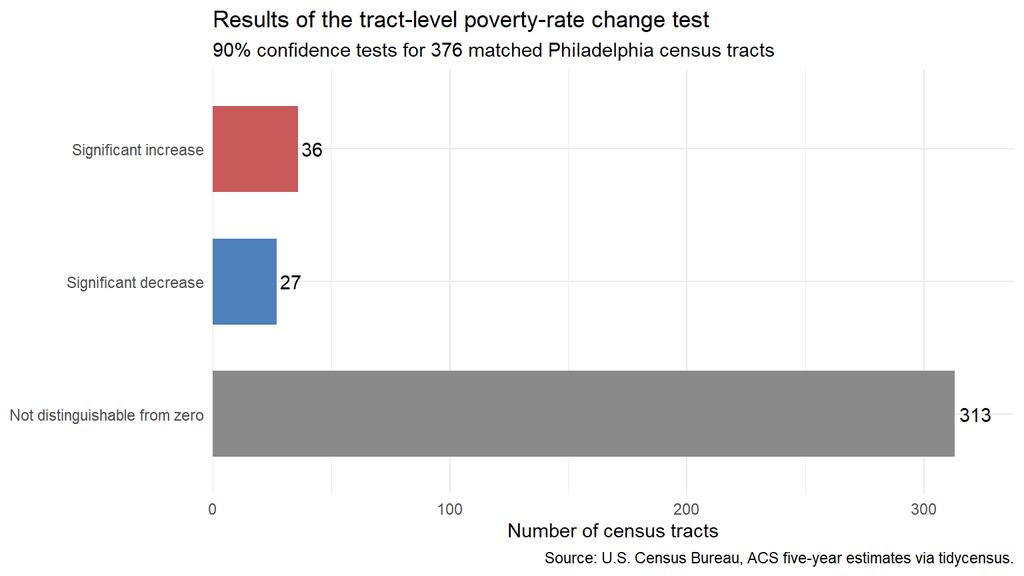

Most Philadelphia census tracts did not have a statistically detectable change in poverty rate.

```r
ggplot(change_counts, aes(x = change_direction, y = n, fill = change_direction)) +
  geom_col(width = 0.65, show.legend = FALSE) +
  geom_text(aes(label = n), hjust = -0.15) +
  coord_flip() +
  scale_fill_manual(
    values = c(
      "Significant increase" = "#C85A5A",
      "Significant decrease" = "#4F81BD",
      "Not distinguishable from zero" = "#8A8A8A"
    )
  ) +
  scale_y_continuous(expand = expansion(mult = c(0, 0.08))) +
  labs(
    title = "Results of the tract-level poverty-rate change test",
    subtitle = "90% confidence tests for 376 matched Philadelphia census tracts",
    x = NULL,
    y = "Number of census tracts",
    caption = "Source: U.S. Census Bureau, ACS five-year estimates via tidycensus."
  ) +
  theme_minimal()
```

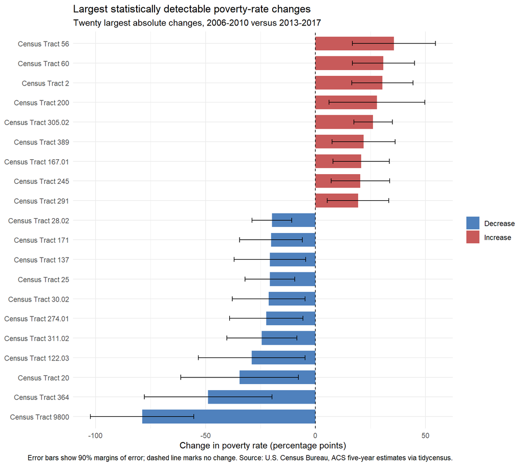

Largest statistically detectable tract-level poverty-rate changes, with 90% margins of error.

```r
change_plot_data <- poverty_tested %>%
  filter(significant) %>%
  arrange(desc(abs(change))) %>%
  slice_head(n = 20) %>%
  mutate(
    tract = str_remove(NAME, ", Philadelphia County, Pennsylvania"),
    change_pp = change * 100,
    moe_diff_pp = moe_diff * 100,
    direction = case_when(
      change > 0 ~ "Increase",
      TRUE ~ "Decrease"
    )
  )

ggplot(change_plot_data, aes(x = reorder(tract, change_pp), y = change_pp)) +
  geom_col(aes(fill = direction), width = 0.7) +
  geom_errorbar(
    aes(ymin = change_pp - moe_diff_pp, ymax = change_pp + moe_diff_pp),
    width = 0.25
  ) +
  geom_hline(yintercept = 0, linetype = "dashed") +
  coord_flip() +
  scale_fill_manual(values = c("Increase" = "#C85A5A", "Decrease" = "#4F81BD")) +
  labs(
    title = "Largest statistically detectable poverty-rate changes",
    subtitle = "Twenty largest absolute changes, 2006-2010 versus 2013-2017",
    x = NULL,
    y = "Change in poverty rate (percentage points)",
    fill = NULL,
    caption = "Error bars show 90% margins of error; dashed line marks no change. Source: U.S. Census Bureau, ACS five-year estimates via tidycensus."
  ) +
  theme_minimal()
```

## Part 3 — Adjudicate

**Supported.** The tract results support the article’s broader point that poverty worsened in some parts of Philadelphia. Of the 376 tracts that could be compared, 36 had a statistically detectable increase in poverty. **Not supported.** The results do not support the idea that poverty increased across the city as a whole: 27 tracts had a detectable decrease, and 313 did not show a clear change. The pattern was mixed rather than citywide.

**Cannot be determined.** I cannot verify the article’s exact figures for Eastwick (12% to 26%), Fairhill (61%), or white poverty in Holmesburg. The article does not publish the neighborhood boundaries or the tracts used in those calculations. The Holmesburg claim would also require a race-specific poverty measure, while this analysis measures overall poverty.

## Part 4 — Rewrite

New American Community Survey data show that poverty changed unevenly across Philadelphia between 2006–10 and 2013–17. Among 376 census tracts with comparable estimates, 36 had a clear increase in poverty and 27 had a clear decrease. In the remaining 313 tracts, the estimated changes were too small relative to survey uncertainty to draw a firm conclusion. The results show worsening poverty in some parts of the city and declines in others, while the direction of change remains unclear across most tracts. The article’s exact figures for Eastwick, Fairhill, and Holmesburg cannot be confirmed because the neighborhood boundaries used in those calculations were not published.